# Study Case 1 - Classification of Airline Passengers Satisfaction

IS388 - A2

september2021

## 0.1 Loading Library

## 0.2 Preparing and Cleaning Data

“Airline Passengers Satisfaction” data description.

The following is a data about airline passengers satisfaction with the services provided by the airline We obtained this data from Kaggle (https://www.kaggle.com/sjleshrac/airlines-customer-satisfaction)

This data shows whether a customer is satisfied with the airlines or not after travelling with them. There are several other measurement or to say feedback taken from the customers as well as their demographic data is also recorded.

The dataset consists of 23 variables which are :

1. Satisfaction(satisfaction) : Airline satisfaction level(Satisfaction and dissatisfaction)
2. Gender(gender) : Gender of the passengers (Female, Male)
3. Customer Type(customerType) : The customer type (Loyal customer, disloyal customer)
4. Age(age) : The actual age of the passengers
5. Type of Travel(travelType) : Purpose of the flight of the passengers (Personal Travel, Business Travel)
6. Class(class) : Travel class in the plane of the passengers (Business, Eco, Eco Plus)
7. Flight distance(flightDistance) : The flight distance of this journey
8. Seat comfort(seatComfort) : Satisfaction level of Seat comfort (0: Not Applicable; 1-5)
9. Departure/Arrival time convenient(timeConvenient) : Satisfaction level of Departure/Arrival time convenient
10. Food and drink(foodDrink) : Satisfaction level of Food and drink
11. Gate location(gateLocation) : Satisfaction level of Gate location
12. Inflight wifi service(wifiService) : Satisfaction level of the inflight wifi service
13. Inflight entertainment(inflightEntertainment) : Satisfaction level of inflight entertainment
14. Online Support(onlineSupport) : satisfaction level of Online Support
15. Ease of Online booking(onlineBooking) : Satisfaction level of online booking
16. On-board service(onboardService) : Satisfaction level of On-board service
17. Leg room service(legRoom) : Satisfaction level of Leg room service
18. Baggage handling(baggageHandling) : Satisfaction level of baggage handling
19. Check-in service(checkinService) : Satisfaction level of Check-in service
20. Cleanliness(cleanliness) : Satisfaction level of Cleanliness
21. Online boarding(onlineBoarding) : Satisfaction level of online boarding
22. Departure Delay in Minutes(departureDelay) : Minutes delayed when departure
23. Arrival Delay in Minutes(arrivalDelay): Minutes delayed when Arrival

The purpose of this project is to build a classification model for airline’s customer satisfaction by using 5 algorithms, which are : Naive bayes, Decision Tree, Logistic Regression, Random Forest, and K-Nearest Neighbors.

```r
#--------------------------Data Introduction--------------------------
# Reading dataset and saving it into 'A2' variable
A2 <- read_excel("A2.xlsx", sheet = "edited")

# Checking the structure of the data
str(A2)
```

```
## tibble [129,880 x 23] (S3: tbl_df/tbl/data.frame)
##  $ satisfaction         : chr [1:129880] "satisfied" "satisfied" "satisfied" "satisfied" ...
##  $ gender               : chr [1:129880] "Female" "Male" "Female" "Female" ...
##  $ customerType         : chr [1:129880] "Loyal Customer" "Loyal Customer" "Loyal Customer" "Loyal Customer" ...
##  $ age                  : num [1:129880] 65 47 15 60 70 30 66 10 56 22 ...
##  $ travelType           : chr [1:129880] "Personal Travel" "Personal Travel" "Personal Travel" "Personal Travel" ...
##  $ class                : chr [1:129880] "Eco" "Business" "Eco" "Eco" ...
##  $ flightDistance       : num [1:129880] 265 2464 2138 623 354 ...
##  $ seatComfort          : num [1:129880] 0 0 0 0 0 0 0 0 0 0 ...
##  $ timeConvenient       : num [1:129880] 0 0 0 0 0 0 0 0 0 0 ...
##  $ foodDrink            : num [1:129880] 0 0 0 0 0 0 0 0 0 0 ...
##  $ gateLocation         : num [1:129880] 2 3 3 3 3 3 3 3 3 3 ...
##  $ wifiService          : num [1:129880] 2 0 2 3 4 2 2 2 5 2 ...
##  $ inflightEntertainment: num [1:129880] 4 2 0 4 3 0 5 0 3 0 ...
##  $ onlineSupport        : num [1:129880] 2 2 2 3 4 2 5 2 5 2 ...
##  $ onlineBooking        : num [1:129880] 3 3 2 1 2 2 5 2 4 2 ...
##  $ onboardService       : num [1:129880] 3 4 3 1 2 5 5 3 4 2 ...
##  $ legRoom              : num [1:129880] 0 4 3 0 0 4 0 3 0 4 ...
##  $ baggageHandling      : num [1:129880] 3 4 4 1 2 5 5 4 1 5 ...
##  $ checkinService       : num [1:129880] 5 2 4 4 4 5 5 5 5 3 ...
##  $ cleanliness          : num [1:129880] 3 3 4 1 2 4 5 4 4 4 ...
##  $ onlineBoarding       : num [1:129880] 2 2 2 3 5 2 3 2 4 2 ...
##  $ departureDelay       : num [1:129880] 0 310 0 0 0 0 17 0 0 30 ...
##  $ arrivalDelay         : num [1:129880] 0 305 0 0 0 0 15 0 0 26 ...
```

```r
# Displaying the first few rows of the data
head(A2)
```

```
## # A tibble: 6 x 23
##   satisfaction gender customerType     age travelType     class   flightDistance
##   <chr>        <chr>  <chr>          <dbl> <chr>          <chr>            <dbl>
## 1 satisfied    Female Loyal Customer    65 Personal Trav~ Eco                265
## 2 satisfied    Male   Loyal Customer    47 Personal Trav~ Busine~           2464
## 3 satisfied    Female Loyal Customer    15 Personal Trav~ Eco               2138
## 4 satisfied    Female Loyal Customer    60 Personal Trav~ Eco                623
## 5 satisfied    Female Loyal Customer    70 Personal Trav~ Eco                354
## 6 satisfied    Male   Loyal Customer    30 Personal Trav~ Eco               1894
## # ... with 16 more variables: seatComfort <dbl>, timeConvenient <dbl>,
## #   foodDrink <dbl>, gateLocation <dbl>, wifiService <dbl>,
## #   inflightEntertainment <dbl>, onlineSupport <dbl>, onlineBooking <dbl>,
## #   onboardService <dbl>, legRoom <dbl>, baggageHandling <dbl>,
## #   checkinService <dbl>, cleanliness <dbl>, onlineBoarding <dbl>,
## #   departureDelay <dbl>, arrivalDelay <dbl>
```

```r
# Showing the summary of the data
summary(A2)
```

```
##  satisfaction          gender          customerType            age
##  Length:129880      Length:129880      Length:129880      Min.   : 7.00
##  Class :character   Class :character   Class :character   1st Qu.:27.00
##  Mode  :character   Mode  :character   Mode  :character   Median :40.00
##                                                           Mean   :39.43
##                                                           3rd Qu.:51.00
##                                                           Max.   :85.00
##
##   travelType           class           flightDistance  seatComfort
##  Length:129880      Length:129880      Min.   :  50   Min.   :0.000
##  Class :character   Class :character   1st Qu.:1359   1st Qu.:2.000
##  Mode  :character   Mode  :character   Median :1925   Median :3.000
##                                        Mean   :1981   Mean   :2.839
##                                        3rd Qu.:2544   3rd Qu.:4.000
##                                        Max.   :6951   Max.   :5.000
##
##  timeConvenient    foodDrink      gateLocation   wifiService
##  Min.   :0.000   Min.   :0.000   Min.   :0.00   Min.   :0.000
##  1st Qu.:2.000   1st Qu.:2.000   1st Qu.:2.00   1st Qu.:2.000
##  Median :3.000   Median :3.000   Median :3.00   Median :3.000
##  Mean   :2.991   Mean   :2.852   Mean   :2.99   Mean   :3.249
##  3rd Qu.:4.000   3rd Qu.:4.000   3rd Qu.:4.00   3rd Qu.:4.000
##  Max.   :5.000   Max.   :5.000   Max.   :5.00   Max.   :5.000
##
##  inflightEntertainment onlineSupport  onlineBooking   onboardService
##  Min.   :0.000         Min.   :0.00   Min.   :0.000   Min.   :0.000
##  1st Qu.:2.000         1st Qu.:3.00   1st Qu.:2.000   1st Qu.:3.000
##  Median :4.000         Median :4.00   Median :4.000   Median :4.000
##  Mean   :3.383         Mean   :3.52   Mean   :3.472   Mean   :3.465
##  3rd Qu.:4.000         3rd Qu.:5.00   3rd Qu.:5.000   3rd Qu.:4.000
##  Max.   :5.000         Max.   :5.00   Max.   :5.000   Max.   :5.000
##
##     legRoom      baggageHandling checkinService   cleanliness
##  Min.   :0.000   Min.   :1.000   Min.   :0.000   Min.   :0.000
##  1st Qu.:2.000   1st Qu.:3.000   1st Qu.:3.000   1st Qu.:3.000
##  Median :4.000   Median :4.000   Median :3.000   Median :4.000
##  Mean   :3.486   Mean   :3.696   Mean   :3.341   Mean   :3.706
##  3rd Qu.:5.000   3rd Qu.:5.000   3rd Qu.:4.000   3rd Qu.:5.000
##  Max.   :5.000   Max.   :5.000   Max.   :5.000   Max.   :5.000
##
##  onlineBoarding  departureDelay     arrivalDelay
##  Min.   :0.000   Min.   :   0.00   Min.   :   0.00
##  1st Qu.:2.000   1st Qu.:   0.00   1st Qu.:   0.00
##  Median :4.000   Median :   0.00   Median :   0.00
##  Mean   :3.353   Mean   :  14.71   Mean   :  15.09
##  3rd Qu.:4.000   3rd Qu.:  12.00   3rd Qu.:  13.00
##  Max.   :5.000   Max.   :1592.00   Max.   :1584.00
##                                    NA's   :393
```

```r
#------------------------Handling Missing Data------------------------
# Checking missing values (missing values or empty values) before Omitting NAs
colSums(is.na(A2) | A2 == '')
```

```
##          satisfaction                gender          customerType
##                     0                     0                     0
##                   age            travelType                 class
##                     0                     0                     0
##        flightDistance           seatComfort        timeConvenient
##                     0                     0                     0
##             foodDrink          gateLocation           wifiService
##                     0                     0                     0
## inflightEntertainment         onlineSupport         onlineBooking
##                     0                     0                     0
##        onboardService               legRoom       baggageHandling
##                     0                     0                     0
##        checkinService           cleanliness        onlineBoarding
##                     0                     0                     0
##        departureDelay          arrivalDelay
##                     0                   393
```

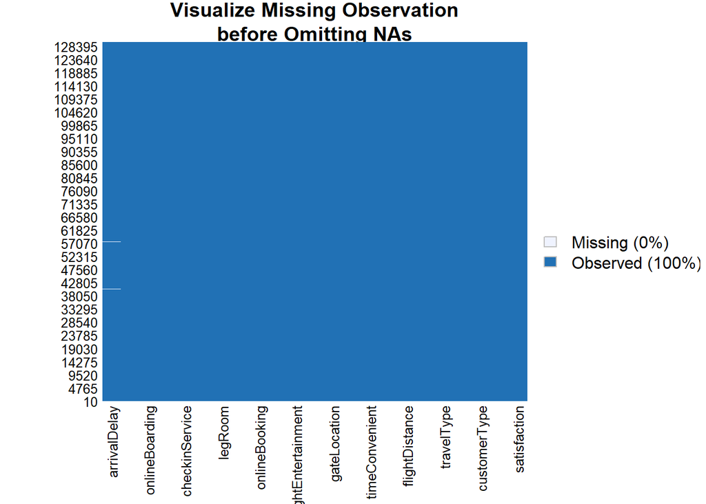

```r
# Visualize the missing data before Omitting NAs
missmap(A2, legend = TRUE, main = "Visualize Missing Observation\nbefore Omitting NAs")
```

```r
# Removing the missing value (NAs)
A2 <-na.omit(A2)
# We remove the missing value because the NAs are too little compare to the whole data

# Checking missing values (missing values or empty values) after Omitting NAs
colSums(is.na(A2) | A2 == '')
```

```
##          satisfaction                gender          customerType
##                     0                     0                     0
##                   age            travelType                 class
##                     0                     0                     0
##        flightDistance           seatComfort        timeConvenient
##                     0                     0                     0
##             foodDrink          gateLocation           wifiService
##                     0                     0                     0
## inflightEntertainment         onlineSupport         onlineBooking
##                     0                     0                     0
##        onboardService               legRoom       baggageHandling
##                     0                     0                     0
##        checkinService           cleanliness        onlineBoarding
##                     0                     0                     0
##        departureDelay          arrivalDelay
##                     0                     0
```

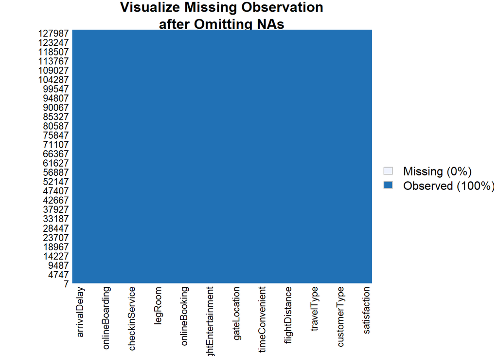

```r
# Visualize the missing data after Omitting NAs
missmap(A2, legend = TRUE, main = "Visualize Missing Observation\nafter Omitting NAs")
```

```r
#------------------------Manipulating Data Type-----------------------
# Changing the target variable into binary.
A2_new <- A2 %>%
  dplyr :: mutate(satisfaction_int = ifelse(satisfaction == "satisfied", 1, 0)) %>%
  dplyr :: select (-satisfaction) %>%
  convert(num(satisfaction_int)) %>%
  na.omit()


# Changing the char data type as factor
#----- gender variable
A2_new$gender <- as.factor(A2_new$gender)
A2_new$gender <- factor(A2_new$gender, levels = c("Male", "Female"))
unclass(A2_new$gender)
```

[output not shown]

[output cut: 2766 more lines]

```r
#----- customerType variable
A2_new$customerType <- as.factor(A2_new$customerType)
A2_new$customerType <- factor(A2_new$customerType, levels = c("Loyal Customer", "disloyal Customer"))
unclass(A2_new$customerType)
```

[output not shown]

[output cut: 2766 more lines]

```r
#----- travelType variable
A2_new$travelType <- as.factor(A2_new$travelType)
A2_new$travelType <- factor(A2_new$travelType, levels = c("Personal Travel", "Business travel"))
unclass(A2_new$travelType)
```

[output not shown]

[output cut: 2766 more lines]

```r
#----- class variable
A2_new$class <- as.factor(A2_new$class)
A2_new$class <- factor(A2_new$class, levels = c("Eco", "Eco Plus","Business"))
unclass(A2_new$class)
```

[output not shown]

[output cut: 2766 more lines]

```r
# Checking the class of each variable in the data (data type) after changing chr to factor
str(A2_new)
```

```
## tibble [129,487 x 23] (S3: tbl_df/tbl/data.frame)
##  $ gender               : Factor w/ 2 levels "Male","Female": 2 1 2 2 2 1 2 1 2 1 ...
##  $ customerType         : Factor w/ 2 levels "Loyal Customer",..: 1 1 1 1 1 1 1 1 1 1 ...
##  $ age                  : num [1:129487] 65 47 15 60 70 30 66 10 56 22 ...
##  $ travelType           : Factor w/ 2 levels "Personal Travel",..: 1 1 1 1 1 1 1 1 1 1 ...
##  $ class                : Factor w/ 3 levels "Eco","Eco Plus",..: 1 3 1 1 1 1 1 1 3 1 ...
##  $ flightDistance       : num [1:129487] 265 2464 2138 623 354 ...
##  $ seatComfort          : num [1:129487] 0 0 0 0 0 0 0 0 0 0 ...
##  $ timeConvenient       : num [1:129487] 0 0 0 0 0 0 0 0 0 0 ...
##  $ foodDrink            : num [1:129487] 0 0 0 0 0 0 0 0 0 0 ...
##  $ gateLocation         : num [1:129487] 2 3 3 3 3 3 3 3 3 3 ...
##  $ wifiService          : num [1:129487] 2 0 2 3 4 2 2 2 5 2 ...
##  $ inflightEntertainment: num [1:129487] 4 2 0 4 3 0 5 0 3 0 ...
##  $ onlineSupport        : num [1:129487] 2 2 2 3 4 2 5 2 5 2 ...
##  $ onlineBooking        : num [1:129487] 3 3 2 1 2 2 5 2 4 2 ...
##  $ onboardService       : num [1:129487] 3 4 3 1 2 5 5 3 4 2 ...
##  $ legRoom              : num [1:129487] 0 4 3 0 0 4 0 3 0 4 ...
##  $ baggageHandling      : num [1:129487] 3 4 4 1 2 5 5 4 1 5 ...
##  $ checkinService       : num [1:129487] 5 2 4 4 4 5 5 5 5 3 ...
##  $ cleanliness          : num [1:129487] 3 3 4 1 2 4 5 4 4 4 ...
##  $ onlineBoarding       : num [1:129487] 2 2 2 3 5 2 3 2 4 2 ...
##  $ departureDelay       : num [1:129487] 0 310 0 0 0 0 17 0 0 30 ...
##  $ arrivalDelay         : num [1:129487] 0 305 0 0 0 0 15 0 0 26 ...
##  $ satisfaction_int     : num [1:129487] 1 1 1 1 1 1 1 1 1 1 ...
##  - attr(*, "na.action")= 'omit' Named int [1:393] 146 247 711 737 819 1163 1268 1302 1911 2035 ...
##   ..- attr(*, "names")= chr [1:393] "146" "247" "711" "737" ...
```

```r
# Changing the factor data type as numeric
A2_new <- A2_new %>% dplyr :: mutate_if(is.factor, as.numeric)

# Checking the class of each variable in the data (data type) after changing everything to factor
sapply(A2_new, class)
```

```
##                gender          customerType                   age
##             "numeric"             "numeric"             "numeric"
##            travelType                 class        flightDistance
##             "numeric"             "numeric"             "numeric"
##           seatComfort        timeConvenient             foodDrink
##             "numeric"             "numeric"             "numeric"
##          gateLocation           wifiService inflightEntertainment
##             "numeric"             "numeric"             "numeric"
##         onlineSupport         onlineBooking        onboardService
##             "numeric"             "numeric"             "numeric"
##               legRoom       baggageHandling        checkinService
##             "numeric"             "numeric"             "numeric"
##           cleanliness        onlineBoarding        departureDelay
##             "numeric"             "numeric"             "numeric"
##          arrivalDelay      satisfaction_int
##             "numeric"             "numeric"
```

## 0.3 Data Visualization; Exploratory Data Analysis

```r
#-----------------------------Preparation-----------------------------
# Changing the char data type as factor
str(A2)
```

```
## tibble [129,487 x 23] (S3: tbl_df/tbl/data.frame)
##  $ satisfaction         : chr [1:129487] "satisfied" "satisfied" "satisfied" "satisfied" ...
##  $ gender               : chr [1:129487] "Female" "Male" "Female" "Female" ...
##  $ customerType         : chr [1:129487] "Loyal Customer" "Loyal Customer" "Loyal Customer" "Loyal Customer" ...
##  $ age                  : num [1:129487] 65 47 15 60 70 30 66 10 56 22 ...
##  $ travelType           : chr [1:129487] "Personal Travel" "Personal Travel" "Personal Travel" "Personal Travel" ...
##  $ class                : chr [1:129487] "Eco" "Business" "Eco" "Eco" ...
##  $ flightDistance       : num [1:129487] 265 2464 2138 623 354 ...
##  $ seatComfort          : num [1:129487] 0 0 0 0 0 0 0 0 0 0 ...
##  $ timeConvenient       : num [1:129487] 0 0 0 0 0 0 0 0 0 0 ...
##  $ foodDrink            : num [1:129487] 0 0 0 0 0 0 0 0 0 0 ...
##  $ gateLocation         : num [1:129487] 2 3 3 3 3 3 3 3 3 3 ...
##  $ wifiService          : num [1:129487] 2 0 2 3 4 2 2 2 5 2 ...
##  $ inflightEntertainment: num [1:129487] 4 2 0 4 3 0 5 0 3 0 ...
##  $ onlineSupport        : num [1:129487] 2 2 2 3 4 2 5 2 5 2 ...
##  $ onlineBooking        : num [1:129487] 3 3 2 1 2 2 5 2 4 2 ...
##  $ onboardService       : num [1:129487] 3 4 3 1 2 5 5 3 4 2 ...
##  $ legRoom              : num [1:129487] 0 4 3 0 0 4 0 3 0 4 ...
##  $ baggageHandling      : num [1:129487] 3 4 4 1 2 5 5 4 1 5 ...
##  $ checkinService       : num [1:129487] 5 2 4 4 4 5 5 5 5 3 ...
##  $ cleanliness          : num [1:129487] 3 3 4 1 2 4 5 4 4 4 ...
##  $ onlineBoarding       : num [1:129487] 2 2 2 3 5 2 3 2 4 2 ...
##  $ departureDelay       : num [1:129487] 0 310 0 0 0 0 17 0 0 30 ...
##  $ arrivalDelay         : num [1:129487] 0 305 0 0 0 0 15 0 0 26 ...
##  - attr(*, "na.action")= 'omit' Named int [1:393] 146 247 711 737 819 1163 1268 1302 1911 2035 ...
##   ..- attr(*, "names")= chr [1:393] "146" "247" "711" "737" ...
```

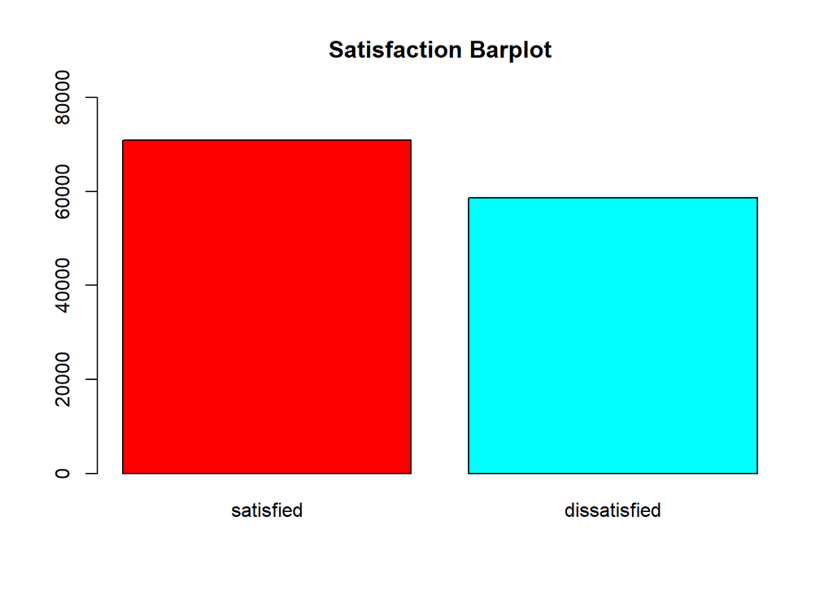

```r
#----- satisfaction variable
A2$satisfaction <- as.factor(A2$satisfaction)
A2$satisfaction <- factor(A2$satisfaction, levels = c("satisfied", "dissatisfied"))

#----- gender variable
A2$gender <- as.factor(A2$gender)
A2$gender <- factor(A2$gender, levels = c("Male", "Female"))

#----- customerType variable
A2$customerType <- as.factor(A2$customerType)
A2$customerType <- factor(A2$customerType, levels = c("Loyal Customer", "disloyal Customer"))

#----- travelType variable
A2$travelType <- as.factor(A2$travelType)
A2$travelType <- factor(A2$travelType, levels = c("Personal Travel", "Business travel"))

#----- class variable
A2$class <- as.factor(A2$class)
A2$class <- factor(A2$class, levels = c("Eco", "Eco Plus","Business"))

#----------------------------Visualization----------------------------
# Categorical type ---------------------------------------------------
tab1 <-table(A2$satisfaction)
barplot(tab1, main = "Satisfaction Barplot", col = rainbow(2), ylim = c(0,80000))
```

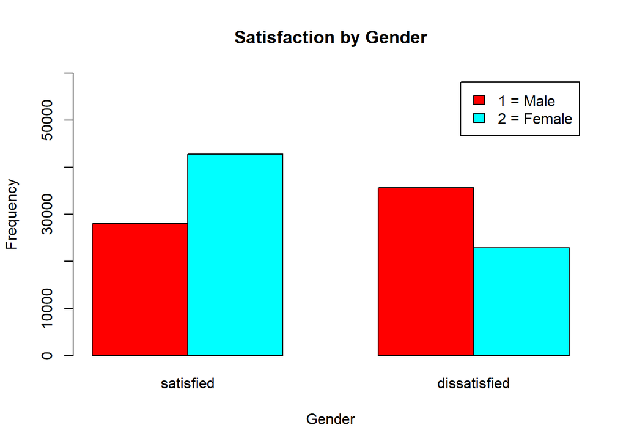

```r
# CONCLUSION : frequency of Satisfied > Dissatisfied

tab2 <- table(A2$gender, A2$satisfaction)
barplot(tab2, main = "Satisfaction by Gender", horiz = FALSE, xlab = "Gender", ylab = "Frequency", ylim = c(0,60000), col = rainbow(2), legend = rownames(A2$gender), beside = TRUE, legend.text = c("1 = Male", "2 = Female"))
```

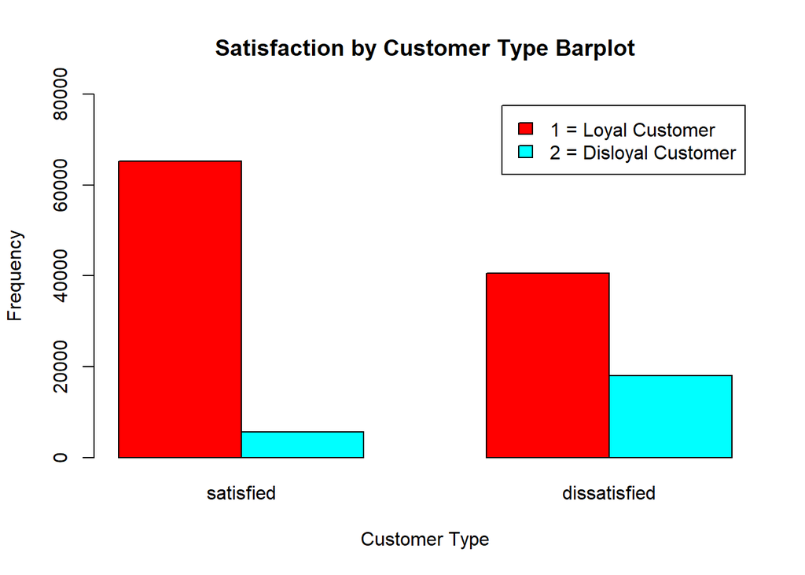

```r
# CONCLUSION : women are mostly satisfied and men are mostly dissatisfied

tab3 <- table(A2$customerType, A2$satisfaction)
barplot(tab3, main = "Satisfaction by Customer Type Barplot", horiz = FALSE, xlab = "Customer Type", ylab = "Frequency", ylim = c(0,80000), col = rainbow(2), legend = rownames(A2$customerType), beside = TRUE, legend.text = c("1 = Loyal Customer", "2 = Disloyal Customer"))
```

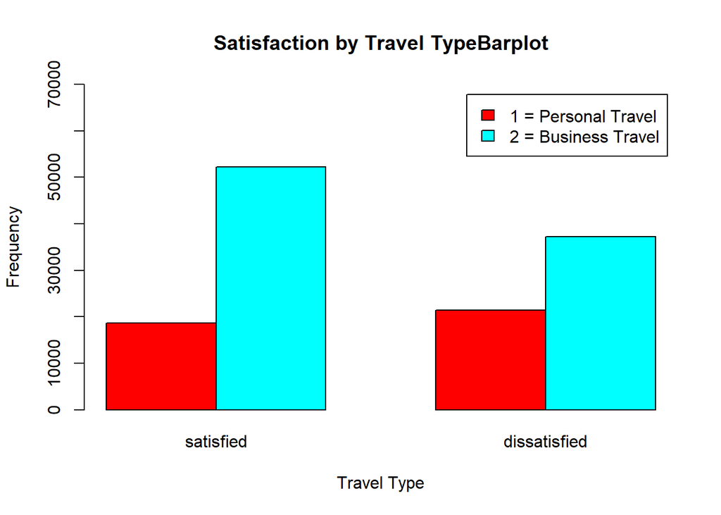

```r
# CONCLUSION : the customer are mostly satisfied and there are more loyal customer than disloyal customer in general

tab4 <- table(A2$travelType, A2$satisfaction)
barplot(tab4, main = "Satisfaction by Travel TypeBarplot", horiz = FALSE, xlab = "Travel Type", ylab = "Frequency", ylim = c(0,70000), col = rainbow(2), legend = rownames(A2$travelType), beside = TRUE, legend.text = c("1 = Personal Travel", "2 = Business Travel"))
```

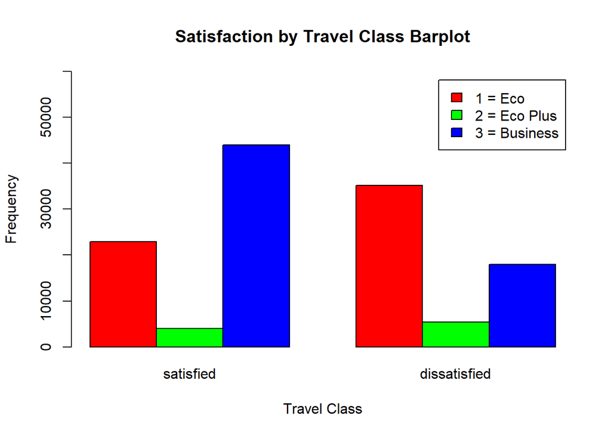

```r
# CONCLUSION : the customer are mostly satisfied and there are more business travel type than personal travel in general

tab5 <- table(A2$class, A2$satisfaction)
barplot(tab5, main = "Satisfaction by Travel Class Barplot", horiz = FALSE, xlab = "Travel Class", ylab = "Frequency", ylim = c(0,60000), col = rainbow(3), legend = rownames(A2$class), beside = TRUE, legend.text = c("1 = Eco", "2 = Eco Plus", "3 = Business"))
```

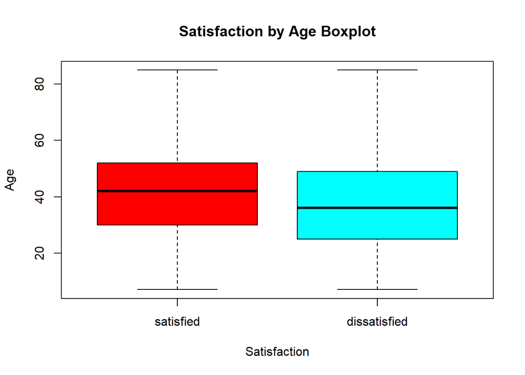

```r
  # CONCLUSION : the business class type are mostly satisfied and the eco class type are mostly dissatisfied; also the eco plus class type is fewer than the other two class type in general

# Categorical x Numerical type ---------------------------------------
boxplot(A2$age ~ A2$satisfaction, main = "Satisfaction by Age Boxplot", xlab = "Satisfaction", ylab = "Age", col = rainbow(2))
```

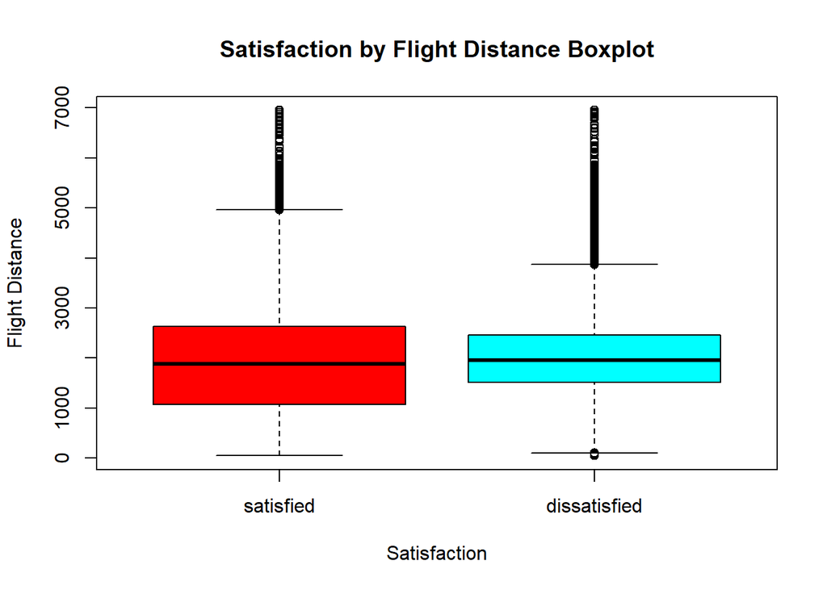

```r
# CONCLUSION : The average age of satisfied customers is higher than the average of dissatisfied customers. This means the satisfied customers are older on average than the dissatisfied customers

boxplot(A2$flightDistance ~ A2$satisfaction, main = "Satisfaction by Flight Distance Boxplot", xlab = "Satisfaction", ylab = "Flight Distance", col = rainbow(2))
```

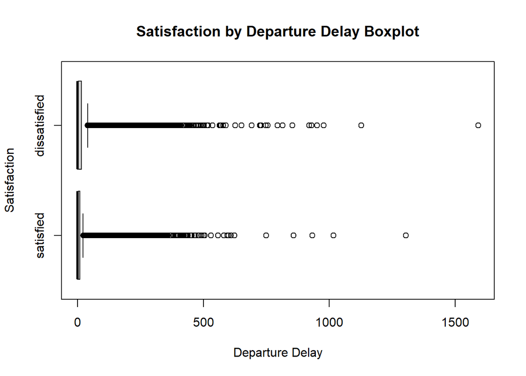

```r
# CONCLUSION : The average distance is quite similar for both satisfied and dissatisfied customer. But, the satisfied customers have wider box and whiskers; this means the range of their flight distance varies more than the dissatisfied customers.

boxplot(A2$departureDelay ~ A2$satisfaction, main = "Satisfaction by Departure Delay Boxplot", xlab = "Departure Delay", ylab = "Satisfaction", horizontal = TRUE)
```

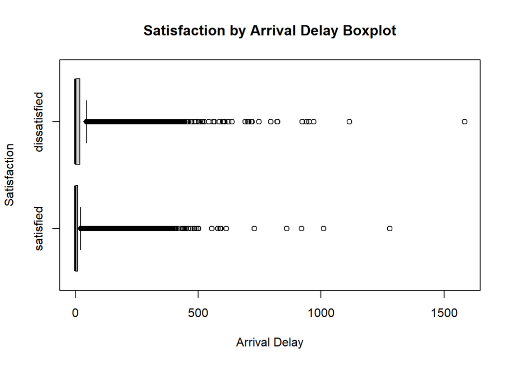

```r
# CONCLUSION : The departure delay of dissatisfied customers varies more than the satisfied customers as it has wider box and whiskers and more outliers.

boxplot(A2$arrivalDelay ~ A2$satisfaction, main = "Satisfaction by Arrival Delay Boxplot", xlab = "Arrival Delay", ylab = "Satisfaction", horizontal = TRUE)
```

```r
# CONCLUSION : The arrival delay of dissatisfied customers varies more than the satisfied customers as it has wider box and whiskers and more outliers.
```

## 0.4 Data Classification : Using 5 Algorithms

### 0.4.1 Preparing Stage

```r
#----------------------------Splitting Data---------------------------
# Split data Training and Testing 80 : 20
Rand <- 16098 # 5 digit
set.seed(Rand) # setting seed

samp <- sample(nrow(A2_new), 0.8 * nrow(A2_new), replace = FALSE)

trainData <- A2_new[samp, ] #for training
nrow(trainData)
```

```
## [1] 103589
```

```r
prop.table(table(trainData$satisfaction_int)) * 100
```

```
##
##        0        1
## 45.32431 54.67569
```

```r
testData <- A2_new[-samp, ] #for testing
nrow(testData)
```

```
## [1] 25898
```

```r
prop.table(table(testData$satisfaction_int)) * 100
```

```
##
##        0        1
## 44.99961 55.00039
```

### 0.4.2 Algorithm 1 (Logistic Regression)

```r
#------------------MULTICOLLINEARITY CHECKING-------------------------
model <- glm(satisfaction_int ~ ., data = A2_new, family = "binomial")
car :: vif(model)
```

```
##                gender          customerType                   age
##              1.064983              1.516882              1.230091
##            travelType                 class        flightDistance
##              1.951764              1.609877              1.196447
##           seatComfort        timeConvenient             foodDrink
##              2.297318              1.725283              2.730681
##          gateLocation           wifiService inflightEntertainment
##              1.558208              2.063328              1.537737
##         onlineSupport         onlineBooking        onboardService
##              1.980764              3.205115              1.596476
##               legRoom       baggageHandling        checkinService
##              1.236046              1.827571              1.175998
##           cleanliness        onlineBoarding        departureDelay
##              1.961296              2.477978             13.418865
##          arrivalDelay
##             13.437537
```

```r
# There are multicollinearity in the variable arrivalDelay and departureDelay because the VIF value is not in between 1-5 range

#---------------------------LOGREG MODEL 1----------------------------
# Fitting the logistic regression model ------------------------------
log_model1 <- glm(satisfaction_int ~  gender + customerType  + age + travelType + class + flightDistance + seatComfort + timeConvenient + foodDrink + gateLocation + wifiService + inflightEntertainment + onlineSupport + onlineBooking + onboardService + legRoom + baggageHandling + checkinService + cleanliness + onlineBoarding, data = trainData, family = "binomial")
summary(log_model1)
```

```
##
## Call:
## glm(formula = satisfaction_int ~ gender + customerType + age +
##     travelType + class + flightDistance + seatComfort + timeConvenient +
##     foodDrink + gateLocation + wifiService + inflightEntertainment +
##     onlineSupport + onlineBooking + onboardService + legRoom +
##     baggageHandling + checkinService + cleanliness + onlineBoarding,
##     family = "binomial", data = trainData)
##
## Deviance Residuals:
##     Min       1Q   Median       3Q      Max
## -2.9886  -0.5820   0.1978   0.5246   3.6741
##
## Coefficients:
##                         Estimate Std. Error z value Pr(>|z|)
## (Intercept)           -7.645e+00  8.551e-02 -89.408  < 2e-16 ***
## gender                 9.397e-01  1.831e-02  51.310  < 2e-16 ***
## customerType          -1.934e+00  2.782e-02 -69.513  < 2e-16 ***
## age                   -7.426e-03  6.365e-04 -11.666  < 2e-16 ***
## travelType             7.946e-01  2.601e-02  30.548  < 2e-16 ***
## class                  3.598e-01  1.178e-02  30.535  < 2e-16 ***
## flightDistance        -1.230e-04  9.510e-06 -12.938  < 2e-16 ***
## seatComfort            2.833e-01  1.029e-02  27.541  < 2e-16 ***
## timeConvenient        -1.994e-01  7.566e-03 -26.359  < 2e-16 ***
## foodDrink             -2.077e-01  1.044e-02 -19.894  < 2e-16 ***
## gateLocation           1.129e-01  8.527e-03  13.236  < 2e-16 ***
## wifiService           -5.896e-02  9.849e-03  -5.986 2.15e-09 ***
## inflightEntertainment  6.929e-01  9.255e-03  74.869  < 2e-16 ***
## onlineSupport          9.371e-02  1.002e-02   9.351  < 2e-16 ***
## onlineBooking          2.237e-01  1.290e-02  17.346  < 2e-16 ***
## onboardService         3.196e-01  9.202e-03  34.733  < 2e-16 ***
## legRoom                2.187e-01  7.837e-03  27.905  < 2e-16 ***
## baggageHandling        1.070e-01  1.038e-02  10.311  < 2e-16 ***
## checkinService         2.931e-01  7.728e-03  37.932  < 2e-16 ***
## cleanliness            8.910e-02  1.076e-02   8.283  < 2e-16 ***
## onlineBoarding         1.577e-01  1.103e-02  14.295  < 2e-16 ***
## ---
## Signif. codes:  0 '***' 0.001 '**' 0.01 '*' 0.05 '.' 0.1 ' ' 1
##
## (Dispersion parameter for binomial family taken to be 1)
##
##     Null deviance: 142698  on 103588  degrees of freedom
## Residual deviance:  80309  on 103568  degrees of freedom
## AIC: 80351
##
## Number of Fisher Scoring iterations: 5
```

```r
# All the variables are very significant

# Making the prediction using data testing ---------------------------
log_pred1 <- predict(log_model1, testData, type = "response")

y_pred_num1 <- ifelse(log_pred1 > 0.5, 1, 0)
y_pred1 <- factor(y_pred_num1, levels=c(0,1))
y_act1 <- testData$satisfaction_int
mean(y_pred1 == y_act1)
```

```
## [1] 0.834659
```

```r
# The prediction's quality is : 0.834659 = 83.46%

#---------------------------LOGREG MODEL 2----------------------------
#We include departureDelay in the model2 and didn't include arrivalDelay -> because they are probably related to each other, that's why they have high VIF value (more than 1-5)
#We only pick one of the two 'multicollinearity variables' and discard the other that was diagnosed 'yes' for having multicollinearity.

# Fitting the logistic regression model ------------------------------
log_model2 <- glm(satisfaction_int ~  gender + customerType  + age + travelType + class + flightDistance + seatComfort + timeConvenient + foodDrink + gateLocation + wifiService + inflightEntertainment + onlineSupport + onlineBooking + onboardService + legRoom + baggageHandling + checkinService + cleanliness + onlineBoarding + departureDelay, data = trainData, family = "binomial")
summary(log_model2)
```

```
##
## Call:
## glm(formula = satisfaction_int ~ gender + customerType + age +
##     travelType + class + flightDistance + seatComfort + timeConvenient +
##     foodDrink + gateLocation + wifiService + inflightEntertainment +
##     onlineSupport + onlineBooking + onboardService + legRoom +
##     baggageHandling + checkinService + cleanliness + onlineBoarding +
##     departureDelay, family = "binomial", data = trainData)
##
## Deviance Residuals:
##     Min       1Q   Median       3Q      Max
## -2.9304  -0.5785   0.1937   0.5201   3.6535
##
## Coefficients:
##                         Estimate Std. Error z value Pr(>|z|)
## (Intercept)           -7.656e+00  8.577e-02 -89.269  < 2e-16 ***
## gender                 9.497e-01  1.838e-02  51.660  < 2e-16 ***
## customerType          -1.941e+00  2.788e-02 -69.635  < 2e-16 ***
## age                   -7.137e-03  6.384e-04 -11.180  < 2e-16 ***
## travelType             8.053e-01  2.610e-02  30.859  < 2e-16 ***
## class                  3.543e-01  1.181e-02  29.991  < 2e-16 ***
## flightDistance        -9.875e-05  9.601e-06 -10.285  < 2e-16 ***
## seatComfort            2.816e-01  1.032e-02  27.280  < 2e-16 ***
## timeConvenient        -1.974e-01  7.579e-03 -26.041  < 2e-16 ***
## foodDrink             -2.152e-01  1.049e-02 -20.515  < 2e-16 ***
## gateLocation           1.163e-01  8.546e-03  13.612  < 2e-16 ***
## wifiService           -6.933e-02  9.923e-03  -6.987 2.81e-12 ***
## inflightEntertainment  6.984e-01  9.309e-03  75.025  < 2e-16 ***
## onlineSupport          9.421e-02  1.005e-02   9.371  < 2e-16 ***
## onlineBooking          2.235e-01  1.297e-02  17.230  < 2e-16 ***
## onboardService         3.193e-01  9.225e-03  34.618  < 2e-16 ***
## legRoom                2.253e-01  7.853e-03  28.691  < 2e-16 ***
## baggageHandling        1.156e-01  1.040e-02  11.115  < 2e-16 ***
## checkinService         2.963e-01  7.751e-03  38.228  < 2e-16 ***
## cleanliness            7.518e-02  1.081e-02   6.954 3.55e-12 ***
## onlineBoarding         1.660e-01  1.110e-02  14.951  < 2e-16 ***
## departureDelay        -5.126e-03  2.501e-04 -20.497  < 2e-16 ***
## ---
## Signif. codes:  0 '***' 0.001 '**' 0.01 '*' 0.05 '.' 0.1 ' ' 1
##
## (Dispersion parameter for binomial family taken to be 1)
##
##     Null deviance: 142698  on 103588  degrees of freedom
## Residual deviance:  79856  on 103567  degrees of freedom
## AIC: 79900
##
## Number of Fisher Scoring iterations: 5
```

```r
# All the variables are very significant

# Making the prediction using data testing ---------------------------
log_pred2 <- predict(log_model2, testData, type = "response")

y_pred_num2 <- ifelse(log_pred2 > 0.5, 1, 0)
y_pred2 <- factor(y_pred_num2, levels=c(0,1))
y_act2 <- testData$satisfaction_int
mean(y_pred2 == y_act2)
```

```
## [1] 0.8365511
```